# Midterm HTML

Leanne Kendall

11/5/2021

1. Data Wrangling
- reading in the data

```r
library(haven)
df <- read_sas("hdd0318cy.sas7bdat")

head(df)
```

```
## # A tibble: 6 x 135
##     yod payfix pay_ub92   age sex   raceethn filler1 filler2 provider   moa
##   <dbl>  <dbl>    <dbl> <dbl> <chr> <chr>    <chr>   <chr>   <chr>    <dbl>
## 1     3     NA       NA    39 2     1        02910   ""      7216         2
## 2     3     NA       NA    59 2     1        02895   ""      7216         1
## 3     3     NA       NA    57 1     1        02888   ""      7216         2
## 4     3     NA       NA    54 2     1        02920   ""      7216         2
## 5     3     NA       NA    54 2     1        02889   ""      7216         1
## 6     3     NA       NA    54 2     1        02889   ""      7216         3
## # ... with 125 more variables: yoa <dbl>, mod <dbl>, admtype <chr>,
## #   asource <chr>, filler3 <chr>, dx1 <chr>, dx2 <chr>, dx3 <chr>, dx4 <chr>,
## #   dx5 <chr>, dx6 <chr>, dx7 <chr>, px1 <chr>, px2 <chr>, px3 <chr>,
## #   px4 <chr>, px5 <chr>, px6 <chr>, px7 <chr>, px8 <chr>, px9 <chr>,
## #   px10 <chr>, preopday <dbl>, los <dbl>, filler4 <chr>, service <chr>,
## #   icu <chr>, ccu <chr>, dispub92 <chr>, payer <chr>, drg <dbl>, trandb <chr>,
## #   randbg <chr>, randbs <chr>, orr <chr>, anes <chr>, seq <chr>, ...
```

- Filter the data to have only patients of the year 2018

```r
library(tidyverse)
df18 <- df %>% filter(yod==18)

head(df18)
```

```
## # A tibble: 6 x 135
##     yod payfix pay_ub92   age sex   raceethn filler1 filler2 provider   moa
##   <dbl>  <dbl>    <dbl> <dbl> <chr> <chr>    <chr>   <chr>   <chr>    <dbl>
## 1    18     NA        9     0 1     1        ""      ""      7214         1
## 2    18     NA        2    76 2     1        ""      ""      7214         1
## 3    18     NA        6    50 2     1        ""      ""      7214        12
## 4    18     NA        4     0 1     7        ""      ""      7214         1
## 5    18     NA       13     0 1     1        ""      ""      7214        12
## 6    18     NA        4     0 2     9        ""      ""      7214        12
## # ... with 125 more variables: yoa <dbl>, mod <dbl>, admtype <chr>,
## #   asource <chr>, filler3 <chr>, dx1 <chr>, dx2 <chr>, dx3 <chr>, dx4 <chr>,
## #   dx5 <chr>, dx6 <chr>, dx7 <chr>, px1 <chr>, px2 <chr>, px3 <chr>,
## #   px4 <chr>, px5 <chr>, px6 <chr>, px7 <chr>, px8 <chr>, px9 <chr>,
## #   px10 <chr>, preopday <dbl>, los <dbl>, filler4 <chr>, service <chr>,
## #   icu <chr>, ccu <chr>, dispub92 <chr>, payer <chr>, drg <dbl>, trandb <chr>,
## #   randbg <chr>, randbs <chr>, orr <chr>, anes <chr>, seq <chr>, ...
```

- Select to work with only certain variables

```r
df18 <- df18[, c("yod", "payfix","pay_ub92","age",
                      "sex","raceethn","provider","moa",
                      "yoa","mod","admtype", "asource" ,
                      "preopday" ,"los", "service" , "icu","ccu",
                      "dispub92", "payer"  ,"drg","trandb",
                      "randbg","randbs","orr", "anes","seq",
                      "lab","dtest", "ther","blood","phar",
                      "other","patcon","bwght","total","tot" ,
                      "ecodub92","b_wt","pt_state","diag_adm","ancilar" ,
                      "campus","er_fee","er_chrg","er_mode","obs_chrg",
                      "obs_hour","psycchrg","nicu_day" )]
head(df18)
```

```
## # A tibble: 6 x 49
##     yod payfix pay_ub92   age sex   raceethn provider   moa   yoa   mod admtype
##   <dbl>  <dbl>    <dbl> <dbl> <chr> <chr>    <chr>    <dbl> <dbl> <dbl> <chr>
## 1    18     NA        9     0 1     1        7214         1    18     1 4
## 2    18     NA        2    76 2     1        7214         1    18     1 3
## 3    18     NA        6    50 2     1        7214        12    17     1 2
## 4    18     NA        4     0 1     7        7214         1    18     1 4
## 5    18     NA       13     0 1     1        7214        12    17     1 4
## 6    18     NA        4     0 2     9        7214        12    17     1 4
## # ... with 38 more variables: asource <chr>, preopday <dbl>, los <dbl>,
## #   service <chr>, icu <chr>, ccu <chr>, dispub92 <chr>, payer <chr>,
## #   drg <dbl>, trandb <chr>, randbg <chr>, randbs <chr>, orr <chr>, anes <chr>,
## #   seq <chr>, lab <chr>, dtest <chr>, ther <chr>, blood <chr>, phar <chr>,
## #   other <chr>, patcon <chr>, bwght <chr>, total <chr>, tot <dbl>,
## #   ecodub92 <chr>, b_wt <chr>, pt_state <chr>, diag_adm <chr>, ancilar <chr>,
## #   campus <chr>, er_fee <chr>, er_chrg <chr>, er_mode <chr>, ...
```

- save the dataset for easier access:

```r
#write_csv(df18, 'midterm.csv')
```

```r
library(tidyverse)
#df18 <- read_csv("midterm.csv")
```

- What are variables that have missing values?

As you can see from the code below, the columns with missing values are payfix, preopday, obs_hour, and nicu_day.

```r
colSums(is.na(df18))
```

```
##      yod   payfix pay_ub92      age      sex raceethn provider      moa
##        0   131478        0        0        0        0        0        0
##      yoa      mod  admtype  asource preopday      los  service      icu
##        0        0        0        0    60486        0        0        0
##      ccu dispub92    payer      drg   trandb   randbg   randbs      orr
##        0        0        0        0        0        0        0        0
##     anes      seq      lab    dtest     ther    blood     phar    other
##        0        0        0        0        0        0        0        0
##   patcon    bwght    total      tot ecodub92     b_wt pt_state diag_adm
##        0        0        0        0        0        0        0        0
##  ancilar   campus   er_fee  er_chrg  er_mode obs_chrg obs_hour psycchrg
##        0        0        0        0        0        0    77343        0
## nicu_day
##   124090
```

- Remove all variables with missing values.

```r
df18$payfix <- NULL
df18$preopday <- NULL
df18$obs_hour <- NULL
df18$nicu_day <- NULL

head(df18)
```

```
## # A tibble: 6 x 45
##     yod pay_ub92   age sex   raceethn provider   moa   yoa   mod admtype asource
##   <dbl>    <dbl> <dbl> <chr> <chr>    <chr>    <dbl> <dbl> <dbl> <chr>   <chr>
## 1    18        9     0 1     1        7214         1    18     1 4       S
## 2    18        2    76 2     1        7214         1    18     1 3       1
## 3    18        6    50 2     1        7214        12    17     1 2       1
## 4    18        4     0 1     7        7214         1    18     1 4       S
## 5    18       13     0 1     1        7214        12    17     1 4       S
## 6    18        4     0 2     9        7214        12    17     1 4       T
## # ... with 34 more variables: los <dbl>, service <chr>, icu <chr>, ccu <chr>,
## #   dispub92 <chr>, payer <chr>, drg <dbl>, trandb <chr>, randbg <chr>,
## #   randbs <chr>, orr <chr>, anes <chr>, seq <chr>, lab <chr>, dtest <chr>,
## #   ther <chr>, blood <chr>, phar <chr>, other <chr>, patcon <chr>,
## #   bwght <chr>, total <chr>, tot <dbl>, ecodub92 <chr>, b_wt <chr>,
## #   pt_state <chr>, diag_adm <chr>, ancilar <chr>, campus <chr>, er_fee <chr>,
## #   er_chrg <chr>, er_mode <chr>, obs_chrg <chr>, psycchrg <chr>
```

- Which variable records the month of admission? Which variable records the month of discharge?

MOA = month of admission MOD = month of discharge

- Which month admitted the most number of patients? Which month admitted the most number of male patients?

Most patients admitted was October with 11,408. October also admitted the most number of male patients at 5,164.

```r
table(df18$moa)
```

```
##
##     1     2     3     4     5     6     7     8     9    10    11    12
## 11309 10259 11073 11174 11404 10690 10962 11199 10666 11408 10636 10698
```

```r
df18_male = filter(df18, sex ==1)
table(df18_male$moa)
```

```
##
##    1    2    3    4    5    6    7    8    9   10   11   12
## 4970 4546 4978 4989 5066 4810 4910 5028 4683 5164 4800 4855
```

- Which month has the most number of teenage female patients?

March has the most teenage female patients with 226.

```r
df18 %>% filter(sex == 2, (age > 12 & age <20)) %>% group_by(moa) %>%  count(moa, sort = TRUE)
```

```
## # A tibble: 12 x 2
## # Groups:   moa [12]
##      moa     n
##    <dbl> <int>
##  1     3   226
##  2     5   220
##  3    10   212
##  4    12   208
##  5     1   207
##  6     9   196
##  7     4   187
##  8    11   177
##  9     2   172
## 10     8   172
## 11     7   171
## 12     6   169
```

- Which provider has the most number of female patients in October?

Provider 7205 has the most number of female patients in October with 1517.

```r
df18 %>% filter(sex == 2, (moa == 10)) %>% group_by(provider) %>%  count(provider, sort = TRUE)
```

```
## # A tibble: 12 x 2
## # Groups:   provider [12]
##    provider     n
##    <chr>    <int>
##  1 7205      1517
##  2 7214      1224
##  3 7204       872
##  4 7210       699
##  5 7209       351
##  6 7206       333
##  7 7213       317
##  8 7201       294
##  9 7216       256
## 10 7202       212
## 11 7211       122
## 12 7215        46
```

- Are female patients older than male patients, on average?

Male patients are older,on average, than female patients.

```r
df18 %>% group_by(sex) %>% summarise( average_age = mean(age))
```

```
## # A tibble: 3 x 2
##   sex   average_age
##   <chr>       <dbl>
## 1 1            51.5
## 2 2            50.9
## 3 9            43
```

- Calculate the average age of patients by months. Which month has the oldest patients on average age?

January has the oldest patients on average.

```r
df18 %>% group_by(moa) %>% summarise(average_age = mean(age)) %>% arrange(-average_age)
```

```
## # A tibble: 12 x 2
##      moa average_age
##    <dbl>       <dbl>
##  1     1        51.8
##  2     6        51.5
##  3    12        51.5
##  4     4        51.4
##  5     7        51.3
##  6     2        51.2
##  7     3        51.1
##  8    11        51.0
##  9     8        50.9
## 10    10        50.8
## 11     5        50.6
## 12     9        50.6
```

- What is the name of the provider that has the highest total charge?

Provider 7205 has the greatest total charge.

```r
df18 %>% group_by(provider) %>% summarise(total_charge = sum(tot)) %>% arrange(-total_charge)
```

```
## # A tibble: 12 x 2
##    provider total_charge
##    <chr>           <dbl>
##  1 7205       1788373499
##  2 7204        678940049
##  3 7214        428480981
##  4 7210        427464111
##  5 7213        240776070
##  6 7206        212906243
##  7 7202        187925007
##  8 7209        163943679
##  9 7201        126539717
## 10 7216        114603878
## 11 7215         77010051
## 12 7211         64990985
```

- What is the name of the provider that has the least total charge for teenage male on average?

Provider 7214 has the least total charge for male teenagers.

```r
df18 %>% filter(sex == 1, (age > 12 & age <20)) %>% group_by(provider) %>% summarise(total_charge = sum(tot)) %>% arrange(total_charge)
```

```
## # A tibble: 12 x 2
##    provider total_charge
##    <chr>           <dbl>
##  1 7214            28950
##  2 7206            93244
##  3 7211           197425
##  4 7209           239161
##  5 7213           474969
##  6 7201           548475
##  7 7202           646562
##  8 7210           706263
##  9 7204           799643
## 10 7216          2430092
## 11 7215         30131977
## 12 7205         32333169
```

- Create a season (Spring, Summer, Fall, Winter) variable. Calculate the length of stays by season. Which season has the longest length of stays on average?

Summer has the longest average length of stays.

```r
df18$season <- case_when(
  df18$moa %in% c(12,1,2)  ~ 'Winter',
  df18$moa %in% c(3,4,5)~ 'Spring',
  df18$moa %in% c(6,7,8)~ 'Summer',
  TRUE ~ 'Fall')
```

```r
df18 %>% group_by(season) %>% summarise(average_los = mean(los)) %>% arrange(-average_los)
```

```
## # A tibble: 4 x 2
##   season average_los
##   <chr>        <dbl>
## 1 Summer        4.96
## 2 Fall          4.96
## 3 Winter        4.93
## 4 Spring        4.84
```

- On average, how much a 20 year-old male get charged for staying 1 day in the Fall season?

```r
df18 %>% filter(sex == 1, age == 20, season == "Fall", los == 1) %>% summarise(average_tot = mean(tot)) %>% arrange(-average_tot)
```

```
## # A tibble: 1 x 1
##   average_tot
##         <dbl>
## 1       16511
```

- Through this preliminary exploration, I was able to learn some interesting things about the data. I learned about the different patient admission trends. For example, October was the month that had the most patient admissions while March was the monch with the most female teenager patient admissions. I also learned that January has the oldest patients on average, and that men in this dataset are slightly older than women on average. Lastly, creating the season variable allowed me to see that summer had the greatest average length of stay. Overall, this exploration helped me understand the data and helped me think about what visualizations I could produce that would provide further insight into the dataset.
2. Data Visualization

```r
df18$moa = as.integer(df18$moa)
#df18$moa = as.Date(df18$moa, %m)
head(df18)
```

```
## # A tibble: 6 x 46
##     yod pay_ub92   age sex   raceethn provider   moa   yoa   mod admtype asource
##   <dbl>    <dbl> <dbl> <chr> <chr>    <chr>    <int> <dbl> <dbl> <chr>   <chr>
## 1    18        9     0 1     1        7214         1    18     1 4       S
## 2    18        2    76 2     1        7214         1    18     1 3       1
## 3    18        6    50 2     1        7214        12    17     1 2       1
## 4    18        4     0 1     7        7214         1    18     1 4       S
## 5    18       13     0 1     1        7214        12    17     1 4       S
## 6    18        4     0 2     9        7214        12    17     1 4       T
## # ... with 35 more variables: los <dbl>, service <chr>, icu <chr>, ccu <chr>,
## #   dispub92 <chr>, payer <chr>, drg <dbl>, trandb <chr>, randbg <chr>,
## #   randbs <chr>, orr <chr>, anes <chr>, seq <chr>, lab <chr>, dtest <chr>,
## #   ther <chr>, blood <chr>, phar <chr>, other <chr>, patcon <chr>,
## #   bwght <chr>, total <chr>, tot <dbl>, ecodub92 <chr>, b_wt <chr>,
## #   pt_state <chr>, diag_adm <chr>, ancilar <chr>, campus <chr>, er_fee <chr>,
## #   er_chrg <chr>, er_mode <chr>, obs_chrg <chr>, psycchrg <chr>, ...
```

- 10 visualizations

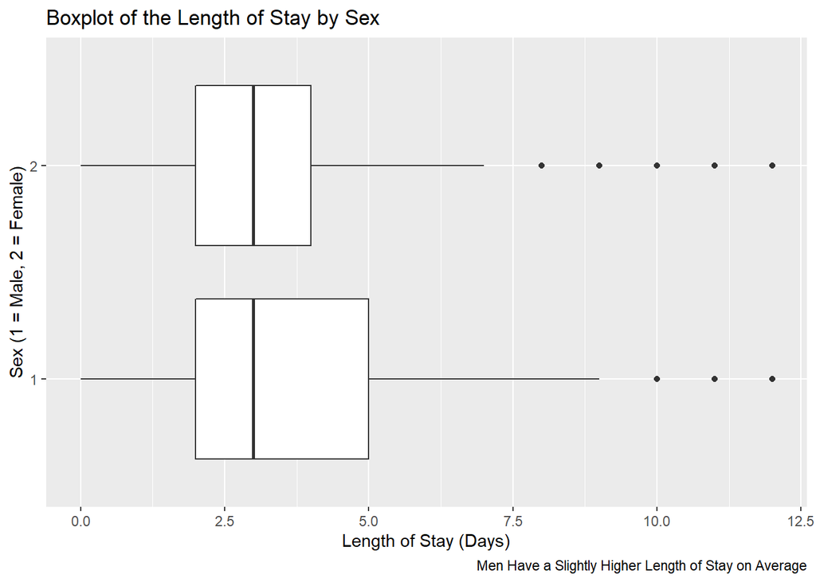

```r
# how does los differ for different sexes?

df18$sex <- as.character(df18$sex)

df18 %>% filter( sex == "1" | sex == "2") %>% ggplot()+
  geom_boxplot(mapping = aes(x = los, y = sex)) + xlim(0,12) +   labs(x='Length of Stay (Days)',
       y = 'Sex (1 = Male, 2 = Female)',
       title = 'Boxplot of the Length of Stay by Sex',
       caption = 'Men Have a Slightly Higher Length of Stay on Average')
```

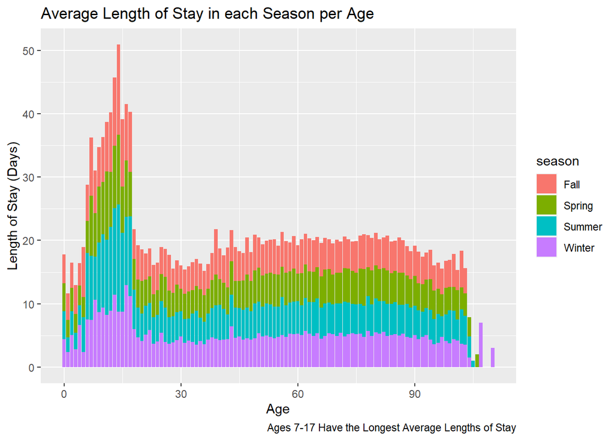

```r
 # Length of stay for each age per season
df18$raceethn <- as.character(df18$raceethn)

df18 %>% group_by(age, season) %>% summarise(average_stay=mean(los)) %>%
  ggplot()+
  geom_col(mapping=aes(x=age, y=average_stay, fill = season)) + labs(x='Age',
       y = 'Length of Stay (Days)',
       title = 'Average Length of Stay in each Season per Age',
       caption = 'Ages 7-17 Have the Longest Average Lengths of Stay')
```

```r
df18 %>% filter(age %in% c(7,8,9,10,11,12,13,14,15,16,17)) %>% count(diag_adm, sort = TRUE)
```

```
## # A tibble: 637 x 2
##    diag_adm     n
##    <chr>    <int>
##  1 F329       286
##  2 F332       221
##  3 R4585      204
##  4 F3481      185
##  5 F4325      164
##  6 F322       107
##  7 J4590       63
##  8 Z5111       58
##  9 F419        56
## 10 F4310       56
## # ... with 627 more rows
```

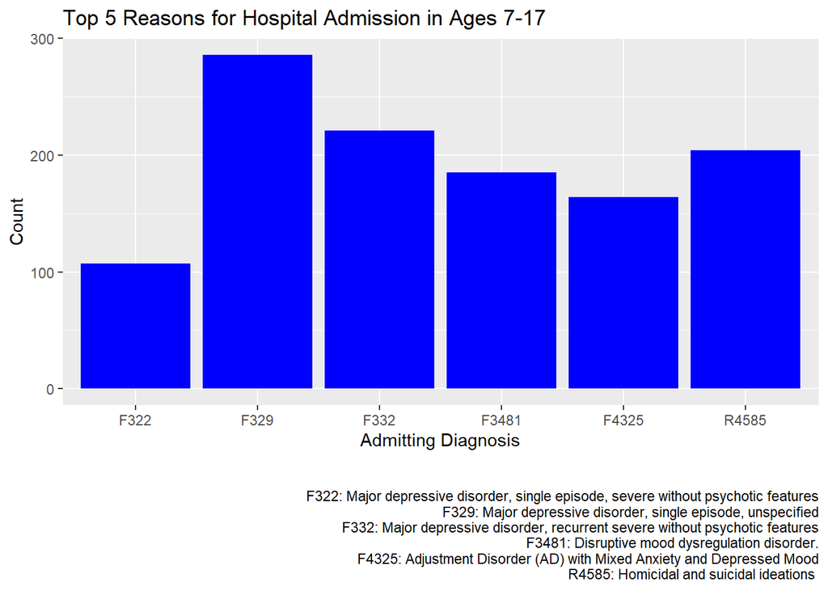

```r
# look at why these ages go to the hospital
# plot the top 5


df18 %>% filter(age %in% c(7,8,9,10,11,12,13,14,15,16,17), diag_adm %in% c("F329", "F332", "R4585", "F3481", "F4325", "F322")) %>% ggplot()+
  geom_bar(mapping = aes(x = diag_adm), fill = 'blue') + labs(x='Admitting Diagnosis',
       y = 'Count',


       title = 'Top 5 Reasons for Hospital Admission in Ages 7-17',
       caption = '

       F322: Major depressive disorder, single episode, severe without psychotic features
       F329: Major depressive disorder, single episode, unspecified
       F332: Major depressive disorder, recurrent severe without psychotic features
       F3481: Disruptive mood dysregulation disorder.
       F4325: Adjustment Disorder (AD) with Mixed Anxiety and Depressed Mood
       R4585: Homicidal and suicidal ideations '
       )
```

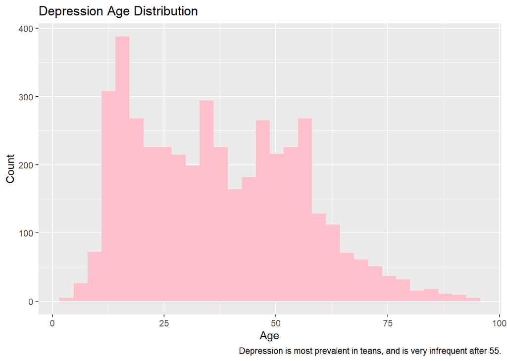

```r
# Let's look at F322, F329, and F332: Major Depressive Disorder

df18 %>% filter(diag_adm %in% c ("F322", "F329", "F332", "F4325")) %>% ggplot()+
  geom_histogram(mapping = aes(x = age), fill = 'pink') + labs(x='Age',
       y = 'Count',

       title = 'Depression Age Distribution', caption = "Depression is most prevalent in teans, and is very infrequent after 55.")
```

```r
# looking into the top reasons why older people are admitted into the hospital


df18 %>% filter(age > 60) %>% count(diag_adm, sort = TRUE)
```

```
## # A tibble: 2,511 x 2
##    diag_adm     n
##    <chr>    <int>
##  1 R0602     2132
##  2 J189      1930
##  3 I509      1425
##  4 R079      1266
##  5 A419      1223
##  6 R4182     1147
##  7 J441      1087
##  8 R55       1080
##  9 R531      1053
## 10 N390      1023
## # ... with 2,501 more rows
```

```r
# Look at the age distributions for the top 4 reasons people are admitted into the hospital


df18 %>% count(diag_adm, sort = TRUE)
```

```
## # A tibble: 4,021 x 2
##    diag_adm     n
##    <chr>    <int>
##  1 Z3800     6811
##  2 Z3801     3181
##  3 R0602     2839
##  4 J189      2695
##  5 R079      2063
##  6 O471      1938
##  7 F332      1901
##  8 F329      1895
##  9 F1020     1882
## 10 A419      1785
## # ... with 4,011 more rows
```

Z3800: Single liveborn infant, delivered vaginally Z3801: Single liveborn infant, delivered by cesarean R0602: Shortness of breath J189: Pneumonia, unspecified organism R079: Chest pain, unspecified

```r
df18$admission_reason <- ifelse(df18$diag_adm == "Z3800" ,"Vaginal Infant Delivery",
                  ifelse(df18$diag_adm  == "Z3801" , "C-Section Infant Delivery",
                   ifelse(df18$diag_adm  == "R0602" , "Shortness of breath",
                    ifelse(df18$diag_adm  == "J189" , "Pneumonia",
                           ifelse(df18$diag_adm  == "R079" , "Chest pain",
                              "Other")))))
```

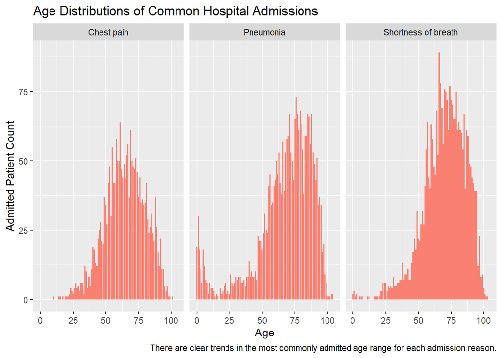

```r
df18 %>% filter(admission_reason %in% c("Shortness of breath", "Pneumonia","Chest pain")) %>%  ggplot()+
  geom_bar(mapping=aes(x=age), fill = 'salmon') + facet_wrap(~admission_reason)+ labs(x='Age',
       y = 'Admitted Patient Count',
       title = 'Age Distributions of Common Hospital Admissions',
       caption = 'There are clear trends in the most commonly admitted age range for each admission reason.')
```

```r
# Seasonality of Mental Health

# List of Most Codes Relating to Mental Health

listx = c("F332", "F3481", "F322", "F333", "F329", "670", "651", "F419", "F410", "F411", "F209", "657", "659")

df18$mental_health_admission <- ifelse(df18$diag_adm %in% listx, 1, 0)

head(df18)
```

```
## # A tibble: 6 x 48
##     yod pay_ub92   age sex   raceethn provider   moa   yoa   mod admtype asource
##   <dbl>    <dbl> <dbl> <chr> <chr>    <chr>    <int> <dbl> <dbl> <chr>   <chr>
## 1    18        9     0 1     1        7214         1    18     1 4       S
## 2    18        2    76 2     1        7214         1    18     1 3       1
## 3    18        6    50 2     1        7214        12    17     1 2       1
## 4    18        4     0 1     7        7214         1    18     1 4       S
## 5    18       13     0 1     1        7214        12    17     1 4       S
## 6    18        4     0 2     9        7214        12    17     1 4       T
## # ... with 37 more variables: los <dbl>, service <chr>, icu <chr>, ccu <chr>,
## #   dispub92 <chr>, payer <chr>, drg <dbl>, trandb <chr>, randbg <chr>,
## #   randbs <chr>, orr <chr>, anes <chr>, seq <chr>, lab <chr>, dtest <chr>,
## #   ther <chr>, blood <chr>, phar <chr>, other <chr>, patcon <chr>,
## #   bwght <chr>, total <chr>, tot <dbl>, ecodub92 <chr>, b_wt <chr>,
## #   pt_state <chr>, diag_adm <chr>, ancilar <chr>, campus <chr>, er_fee <chr>,
## #   er_chrg <chr>, er_mode <chr>, obs_chrg <chr>, psycchrg <chr>, ...
```

[figure not shown]

```r
df18 %>% filter(mental_health_admission == 1, yoa == 18) %>%  count(moa) %>% ggplot()+
  geom_point(mapping=aes(x=moa, y = n))+
  geom_smooth(mapping=aes(x=moa , y = n ))+labs(x='Month',
       y = 'Admitted Patient Count',
       title = 'Monthly Mental Health Hospital Admissions in 2018',
       caption = 'Mental Health hospital admissions trend downwards from January on. There is also a peak in May. ')
```

```r
# Let's see if we see different trends in mental health admission for different age groups

# Have to bin age then use each bin as a facet

df18$age_bin <- cut(df18$age,
                      breaks = c(-Inf, 10, 20, 30, 40, 50, 60, 70, 80 ,Inf),
                      labels=c('0-10','10-20','20-30', '30-40', '40-50', '50-60', '60-70', '70-80', '80+'))

head(df18)
```

```
## # A tibble: 6 x 49
##     yod pay_ub92   age sex   raceethn provider   moa   yoa   mod admtype asource
##   <dbl>    <dbl> <dbl> <chr> <chr>    <chr>    <int> <dbl> <dbl> <chr>   <chr>
## 1    18        9     0 1     1        7214         1    18     1 4       S
## 2    18        2    76 2     1        7214         1    18     1 3       1
## 3    18        6    50 2     1        7214        12    17     1 2       1
## 4    18        4     0 1     7        7214         1    18     1 4       S
## 5    18       13     0 1     1        7214        12    17     1 4       S
## 6    18        4     0 2     9        7214        12    17     1 4       T
## # ... with 38 more variables: los <dbl>, service <chr>, icu <chr>, ccu <chr>,
## #   dispub92 <chr>, payer <chr>, drg <dbl>, trandb <chr>, randbg <chr>,
## #   randbs <chr>, orr <chr>, anes <chr>, seq <chr>, lab <chr>, dtest <chr>,
## #   ther <chr>, blood <chr>, phar <chr>, other <chr>, patcon <chr>,
## #   bwght <chr>, total <chr>, tot <dbl>, ecodub92 <chr>, b_wt <chr>,
## #   pt_state <chr>, diag_adm <chr>, ancilar <chr>, campus <chr>, er_fee <chr>,
## #   er_chrg <chr>, er_mode <chr>, obs_chrg <chr>, psycchrg <chr>, ...
```

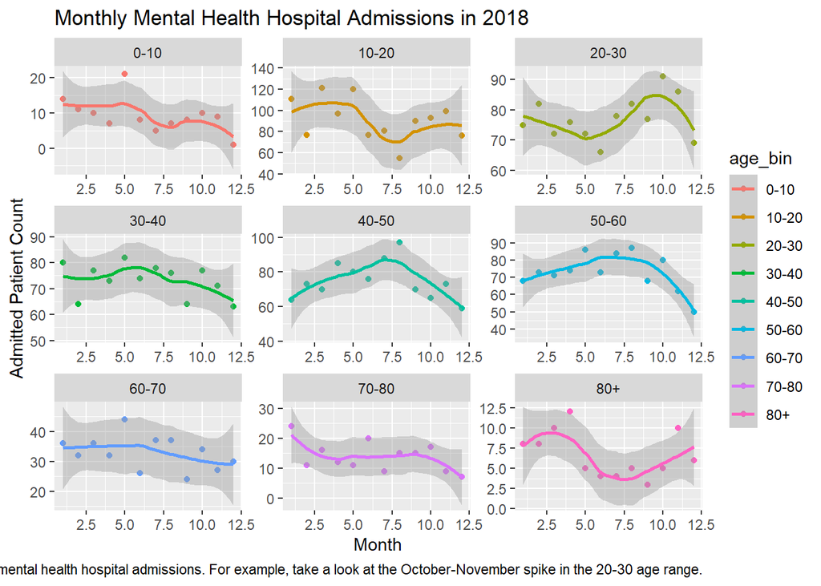

```r
df18 %>% filter(mental_health_admission == 1, yoa == 18) %>% group_by(age_bin) %>%   count(moa) %>% ggplot()+
  geom_point(mapping=aes(x=moa, y = n, color = age_bin)) +
  geom_smooth(mapping=aes(x=moa , y = n, color = age_bin)) + facet_wrap(~age_bin, scale = 'free') +
  labs(x='Month',
       y = 'Admitted Patient Count',
       title = 'Monthly Mental Health Hospital Admissions in 2018',
       caption = 'Different age groups have distinct trends in mental health hospital admissions. For example, take a look at the October-November spike in the 20-30 age range.')
```

```r
df18 %>% count(pt_state, sort = TRUE)
```

```
## # A tibble: 56 x 2
##    pt_state      n
##    <chr>     <int>
##  1 RI       115954
##  2 MA         8493
##  3 FC         4451
##  4 CT         1690
##  5 FL          196
##  6 NY          155
##  7 NJ           60
##  8 NH           48
##  9 XX           47
## 10 CA           35
## # ... with 46 more rows
```

[figure not shown]

```r
# Mental Health and Location
library(gganimate)

df18 %>% filter(mental_health_admission == 1, yoa == 18, pt_state %in% c("MA", "CT", "RI", "FC")) %>% group_by(pt_state) %>% count(moa) %>%
  ggplot(aes(y= n,
            x=moa,
            color=pt_state))+
  geom_line()+ facet_wrap(~pt_state, scales = "free") +
  geom_point(size=3)+
  transition_reveal(moa)  + labs(x='Month',
       y = 'Admitted Patient Count',
       title = 'Mental Health Hospital Admissions in 2018',
       caption = 'Mental Health hospital admissions show similar trends in different states. There is a midyear (either may or june) peak in MA, CT, and RI. They also all decrease in December.')
```

```r
# let's look further into race


#Race

#1 = White
#2 = Black
#3 = Asian
#4 = American Indian
#5   =  Hispanic
#6   =  Other
#9   =  Unknown Race
#blank = Missing/Unknown

df18$Race <- ifelse(df18$raceethn == 1 ,"White",
                  ifelse(df18$raceethn == 2 , "Black",
                   ifelse(df18$raceethn == 3 , "Asian",
                    ifelse(df18$raceethn == 4 , "American Indian",
                           ifelse(df18$raceethn == 5 , "Hispanic",
                              "Unknown")))))

head(df18)
```

```
## # A tibble: 6 x 50
##     yod pay_ub92   age sex   raceethn provider   moa   yoa   mod admtype asource
##   <dbl>    <dbl> <dbl> <chr> <chr>    <chr>    <int> <dbl> <dbl> <chr>   <chr>
## 1    18        9     0 1     1        7214         1    18     1 4       S
## 2    18        2    76 2     1        7214         1    18     1 3       1
## 3    18        6    50 2     1        7214        12    17     1 2       1
## 4    18        4     0 1     7        7214         1    18     1 4       S
## 5    18       13     0 1     1        7214        12    17     1 4       S
## 6    18        4     0 2     9        7214        12    17     1 4       T
## # ... with 39 more variables: los <dbl>, service <chr>, icu <chr>, ccu <chr>,
## #   dispub92 <chr>, payer <chr>, drg <dbl>, trandb <chr>, randbg <chr>,
## #   randbs <chr>, orr <chr>, anes <chr>, seq <chr>, lab <chr>, dtest <chr>,
## #   ther <chr>, blood <chr>, phar <chr>, other <chr>, patcon <chr>,
## #   bwght <chr>, total <chr>, tot <dbl>, ecodub92 <chr>, b_wt <chr>,
## #   pt_state <chr>, diag_adm <chr>, ancilar <chr>, campus <chr>, er_fee <chr>,
## #   er_chrg <chr>, er_mode <chr>, obs_chrg <chr>, psycchrg <chr>, ...
```

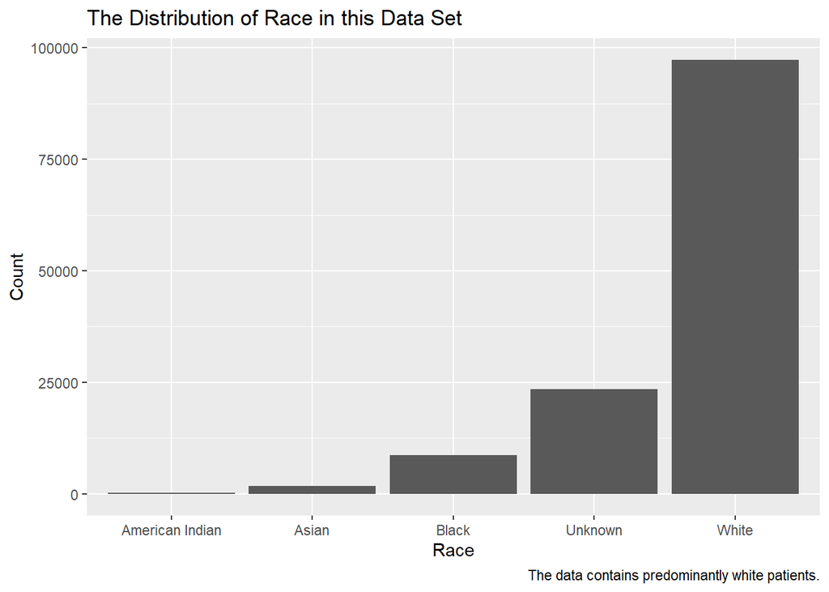

```r
# Race Distribution
df18  %>% ggplot()+
  geom_bar(mapping = aes(x = Race)) + labs(x='Race',
       y = 'Count',


       title = 'The Distribution of Race in this Data Set',
       caption = "The data contains predominantly white patients.")
```

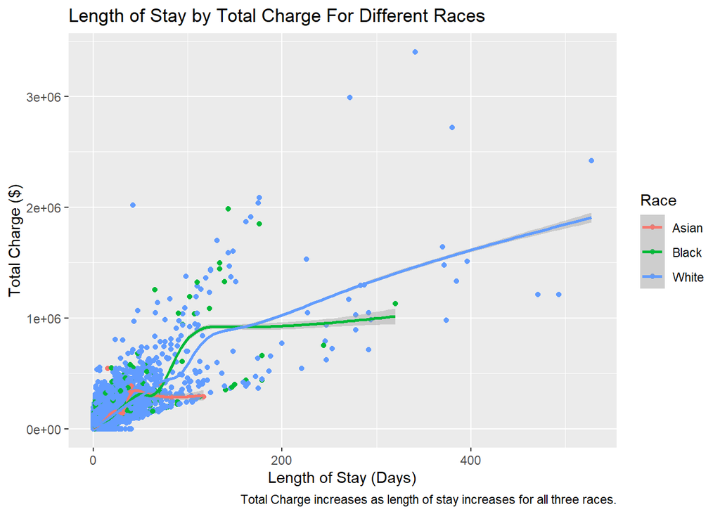

```r
df18 %>% filter(Race %in% c("White", "Black", "Asian")) %>% ggplot()+
  geom_point(mapping=aes(x=los, y=tot, color=Race))+
  geom_smooth(mapping=aes(x=los, y=tot, color=Race))+labs(x='Length of Stay (Days)',
       y = 'Total Charge ($)',
       title = 'Length of Stay by Total Charge For Different Races',
       caption = 'Total Charge increases as length of stay increases for all three races.')
```

```r
library(lubridate)
d1 <- df18 %>% filter(yoa == 18, Race %in% c("White", "Black", "Asian", "Hispanic")) %>% group_by(moa, Race) %>% summarise(mean = mean(tot))
```

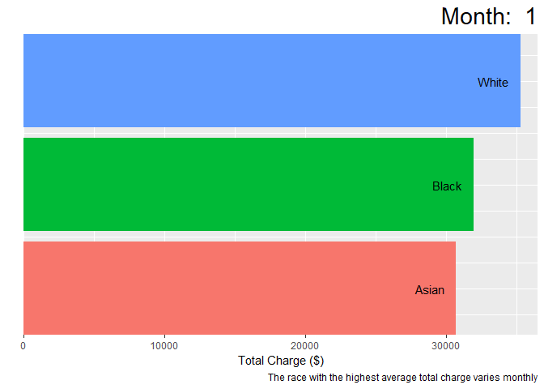

```r
d2 <- d1 %>% group_by(moa) %>% mutate(rank=rank(-mean)) %>% ungroup()

d3 <- d2 %>% filter(rank <= 10)

a1 <- d3 %>% ggplot(aes(x=rank, y=mean, group=Race, fill=Race, label=Race)) + geom_col() +
    geom_text(aes(y = mean, label = Race), hjust = 1.4)+
    coord_flip(clip = "off", expand = FALSE) +scale_x_reverse()+
    labs(title = 'Month:  {closest_state}', x='', y='Total Charge ($)', fill='state' , caption = "The race with the highest average total charge varies monthly")+
    theme(plot.title = element_text(hjust = 1, size = 22),
          axis.ticks.y = element_blank(),
          axis.text.y  = element_blank(), legend.position = "none") +
    transition_states(moa)+
    ease_aes("cubic-in-out")

animate(a1, nframes = 400)
```

- Summary: I began by looking at the length of stay by sex and found that men stay longer on average than women do. I then looked at the length of stay by age and by season, where I found that ages 7-17 have the longest lengths of stay. This made me wonder what these ages were most commonly admitted for. I found and plotted the top 6 reasons for ages 7-17 to be admitted, which included major depressive disorder, disruptive mood dysregulation disorder, adjustment disorder (AD), and homicidal and suicidal ideations. Because 3 out of 6 of the reasons were depression, I looked at the age distribution of these three depression codes and found that depression is most prevalent in teens, and has a big drop off after age 55. I then wondered why individuals in general were commonly admitted into the hospital. The common reasons were infant delivery, shortness of breath, pneumonia, and chest pain. I returned to exploring mental health and wanted to look at seasonal trends of mental health related hospital admissions. I found as many hospital codes related to mental health as I could online and created a variable that signified if this patient was admitted for a mental health reason. I then plotted the amount of admissions against the months in 2018. I saw peaks in January and May. I then binned age so I could view the same trend but by age group. I then looked into location, and found that Massachusetts, Connecticut, and Rhode Island follow similar mental health admission trends, peaking in either may or June. I took a look at race and found the data set was largely white patients. I then plotted the average length of stay against the total charge for each race. The variables appear to be positively correlated (longer stay = higher charge) for all races. Finally, I created a bar race that shows the average total charge for each race in every month.
3. Predictive Models

```r
median(df18$tot)
```

```
## [1] 21854
```

```r
# create the target variable

df18$target <- ifelse(df18$tot < median(df18$tot), "low", "high")

head(df18)
```

```
## # A tibble: 6 x 51
##     yod pay_ub92   age sex   raceethn provider   moa   yoa   mod admtype asource
##   <dbl>    <dbl> <dbl> <chr> <chr>    <chr>    <int> <dbl> <dbl> <chr>   <chr>
## 1    18        9     0 1     1        7214         1    18     1 4       S
## 2    18        2    76 2     1        7214         1    18     1 3       1
## 3    18        6    50 2     1        7214        12    17     1 2       1
## 4    18        4     0 1     7        7214         1    18     1 4       S
## 5    18       13     0 1     1        7214        12    17     1 4       S
## 6    18        4     0 2     9        7214        12    17     1 4       T
## # ... with 40 more variables: los <dbl>, service <chr>, icu <chr>, ccu <chr>,
## #   dispub92 <chr>, payer <chr>, drg <dbl>, trandb <chr>, randbg <chr>,
## #   randbs <chr>, orr <chr>, anes <chr>, seq <chr>, lab <chr>, dtest <chr>,
## #   ther <chr>, blood <chr>, phar <chr>, other <chr>, patcon <chr>,
## #   bwght <chr>, total <chr>, tot <dbl>, ecodub92 <chr>, b_wt <chr>,
## #   pt_state <chr>, diag_adm <chr>, ancilar <chr>, campus <chr>, er_fee <chr>,
## #   er_chrg <chr>, er_mode <chr>, obs_chrg <chr>, psycchrg <chr>, ...
```

```r
# input variables
# “age”,“sex”,“raceethn”,“provider”,“moa”,“mod”,“admtype”,“campus”, ‘los’

df_for_model <-df18[, c("age","sex","raceethn","provider","moa","mod","admtype","campus", "los", "target")]


# the target variable is the 10th column
names(df_for_model)
```

```
##  [1] "age"      "sex"      "raceethn" "provider" "moa"      "mod"
##  [7] "admtype"  "campus"   "los"      "target"
```

```r
#make sure all categorical variables are factors

str(df_for_model)
```

```
## tibble [131,478 x 10] (S3: tbl_df/tbl/data.frame)
##  $ age     : num [1:131478] 0 76 50 0 0 0 0 0 70 25 ...
##   ..- attr(*, "label")= chr " patient age at admission"
##  $ sex     : chr [1:131478] "1" "2" "2" "1" ...
##  $ raceethn: chr [1:131478] "1" "1" "1" "7" ...
##  $ provider: chr [1:131478] "7214" "7214" "7214" "7214" ...
##   ..- attr(*, "label")= chr " provider"
##   ..- attr(*, "format.sas")= chr "$PROVID"
##  $ moa     : int [1:131478] 1 1 12 1 12 12 1 1 1 12 ...
##  $ mod     : num [1:131478] 1 1 1 1 1 1 1 1 1 1 ...
##   ..- attr(*, "label")= chr " month of discharge  mm"
##   ..- attr(*, "format.sas")= chr "MONTHNME"
##  $ admtype : chr [1:131478] "4" "3" "2" "4" ...
##   ..- attr(*, "label")= chr " admission type"
##   ..- attr(*, "format.sas")= chr "$ADMTYPE"
##  $ campus  : chr [1:131478] "0" "0" "0" "0" ...
##  $ los     : num [1:131478] 2 1 3 4 35 17 2 3 2 12 ...
##   ..- attr(*, "label")= chr " length of stay,in days for hosp[in hours for ED"
##  $ target  : chr [1:131478] "low" "high" "high" "low" ...
```

```r
df_for_model$target <- factor(df_for_model$target)
df_for_model$raceethn <- factor(df_for_model$raceethn)
df_for_model$sex <- factor(df_for_model$sex)
df_for_model$provider <- factor(df_for_model$provider)
df_for_model$moa <- factor(df_for_model$moa)
df_for_model$mod <- factor(df_for_model$mod)
df_for_model$campus <- factor(df_for_model$campus)
df_for_model$admtype <- factor(df_for_model$admtype)

str(df_for_model)
```

```
## tibble [131,478 x 10] (S3: tbl_df/tbl/data.frame)
##  $ age     : num [1:131478] 0 76 50 0 0 0 0 0 70 25 ...
##   ..- attr(*, "label")= chr " patient age at admission"
##  $ sex     : Factor w/ 3 levels "1","2","9": 1 2 2 1 1 2 2 2 2 2 ...
##  $ raceethn: Factor w/ 8 levels "","1","2","3",..: 2 2 2 7 2 8 2 2 2 2 ...
##  $ provider: Factor w/ 12 levels "7201","7202",..: 10 10 10 10 10 10 10 10 10 10 ...
##  $ moa     : Factor w/ 12 levels "1","2","3","4",..: 1 1 12 1 12 12 1 1 1 12 ...
##  $ mod     : Factor w/ 12 levels "1","2","3","4",..: 1 1 1 1 1 1 1 1 1 1 ...
##  $ admtype : Factor w/ 7 levels "","1","2","3",..: 5 4 3 5 5 5 5 5 3 3 ...
##  $ campus  : Factor w/ 4 levels "0","1","3","4": 1 1 1 1 1 1 1 1 1 1 ...
##  $ los     : num [1:131478] 2 1 3 4 35 17 2 3 2 12 ...
##   ..- attr(*, "label")= chr " length of stay,in days for hosp[in hours for ED"
##  $ target  : Factor w/ 2 levels "high","low": 2 1 1 2 1 1 2 2 1 1 ...
```

```r
# remove nulls

df_for_model = drop_na(df_for_model)
```

```r
library(caret)
set.seed(2020)
splitIndex <- createDataPartition(df_for_model$target, p = .10,
                                  list = FALSE)
df_train <- df_for_model[ splitIndex,]
df_test <- df_for_model[-splitIndex,]
```

- Train a decision tree using rpart. Plot the decision tree. Plot the variable importance ranked by the tree.

```r
library(rpart)

tree_model <- rpart(target ~ ., data = df_train,
                 control = rpart.control(maxdepth = 5))

tree_model$variable.importance
```

```
##         los     admtype    provider         age      campus    raceethn
## 1830.588014  460.090521  406.667500  228.381227  114.350093   24.032669
##         sex
##    0.792107
```

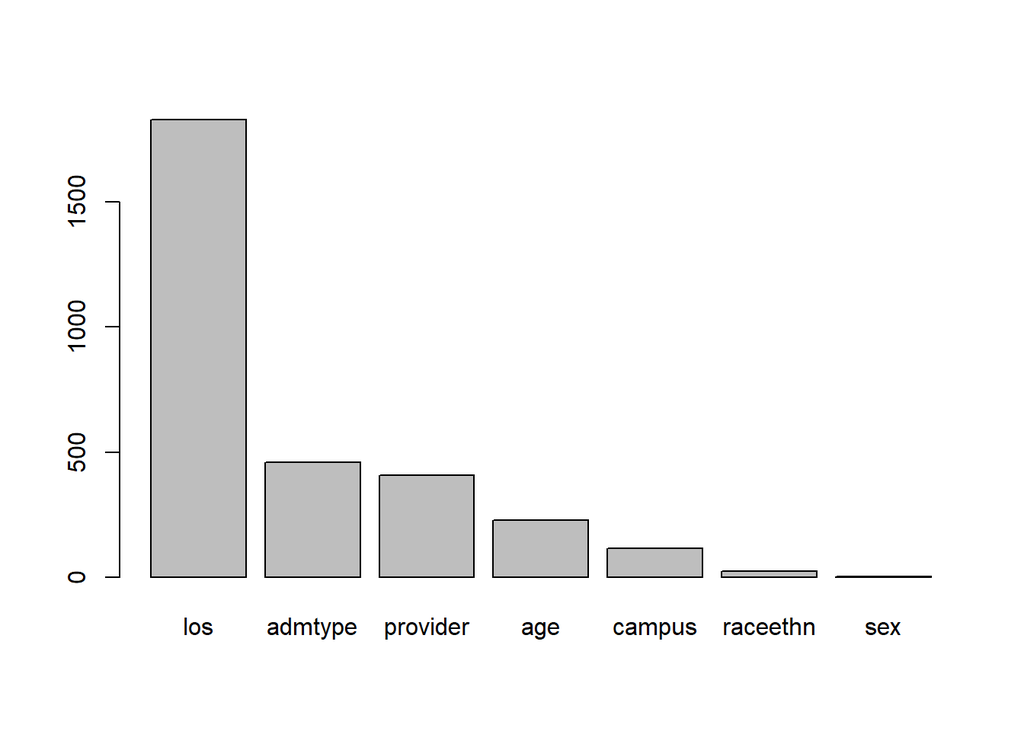

```r
barplot(tree_model$variable.importance)
```

- Using caret for this question. Set Training Control to be: Use Cross-Validation of 5 folds across all models. Train & tune at least 3 different models (i.e. three different values for method= in the train function of caret). Plot the hyper-parameter tuning plots for each model.

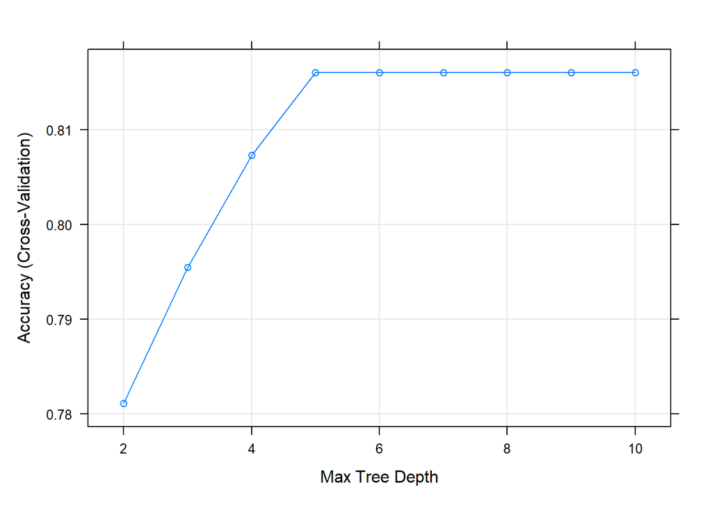

```r
# Decide the range of the maxdepth to search for the best
tuneGrid = expand.grid(maxdepth = 2:10)
# Cross-Validation
trControl = trainControl(method = "cv",
                         number = 5)
# first approach
approach1 <- train(target~., data=df_train,
                                method = "rpart2",
                                trControl = trControl,
                                tuneGrid = tuneGrid)

# Plot the results
plot(approach1)
```

```r
pred <- predict(approach1, df_test)
cm <- confusionMatrix(data = pred, reference = df_test$target, positive = "high")
cm$overall[1]
```

```
## Accuracy
## 0.814196
```

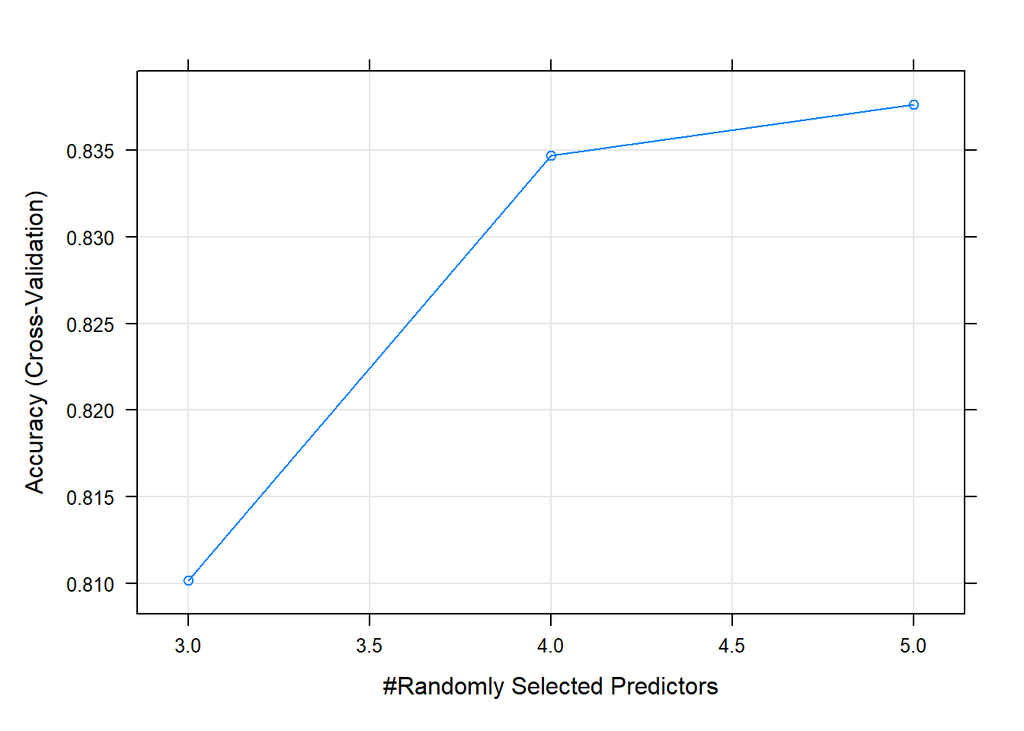

```r
# Random Forest Model

# Decide the range of the mtry to search for the best
tuneGrid = expand.grid(mtry = 3:5)
# Tell caret to do 10 - fold cross-Validation
trControl = trainControl(method = "cv",
                         number = 5)
# train a forest using above setup
forest_rf <- train(target~., data=df_train,
                                method = "rf",
                                trControl = trControl,
                                tuneGrid = tuneGrid)

plot(forest_rf)
```

```r
# lda model

getModelInfo('lda')$lda$parameters
```

```
##   parameter     class     label
## 1 parameter character parameter
```

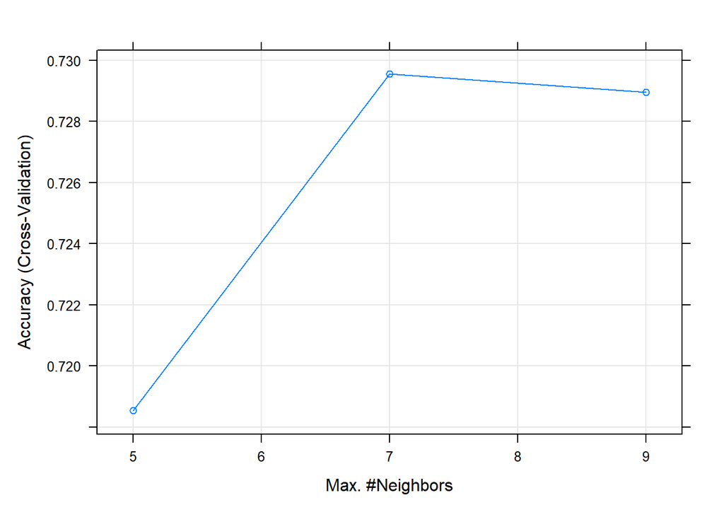

```r
trControl = trainControl(method = "cv",
                         number = 5)

knear <- train(target~., data=df_train,
                    method = "kknn",
                    trControl = trControl)
plot(knear)
```

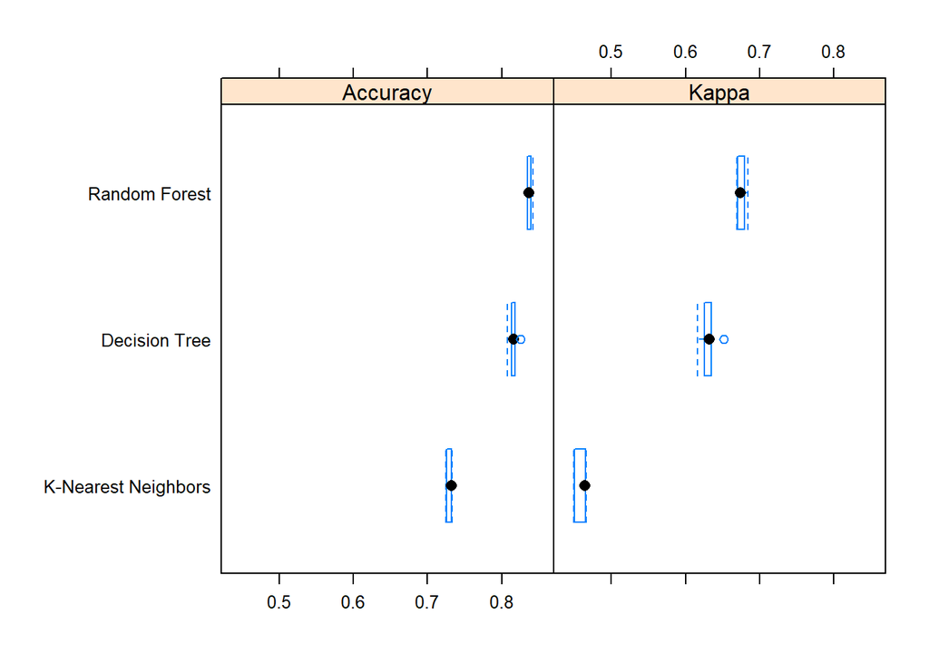

```r
results <- resamples(list('Decision Tree' = approach1,
                          'Random Forest' = forest_rf,
                          'K-Nearest Neighbors'= knear))
bwplot(results)
```

```r
# Best Model: Random Forest

pred <- predict(forest_rf, df_test)
cm <- confusionMatrix(data = pred, reference = df_test$target, positive = "high")
cm$overall[1]
```

```
##  Accuracy
## 0.8371405
```

- Create another target variable (binary), decide the input variables and redo 1 to 5.

```r
# Minor or Adult ?

df2_for_model <- df18

df2_for_model$target <- ifelse(df2_for_model$age < 18, "minor", "adult")

head(df2_for_model)
```

```
## # A tibble: 6 x 51
##     yod pay_ub92   age sex   raceethn provider   moa   yoa   mod admtype asource
##   <dbl>    <dbl> <dbl> <chr> <chr>    <chr>    <int> <dbl> <dbl> <chr>   <chr>
## 1    18        9     0 1     1        7214         1    18     1 4       S
## 2    18        2    76 2     1        7214         1    18     1 3       1
## 3    18        6    50 2     1        7214        12    17     1 2       1
## 4    18        4     0 1     7        7214         1    18     1 4       S
## 5    18       13     0 1     1        7214        12    17     1 4       S
## 6    18        4     0 2     9        7214        12    17     1 4       T
## # ... with 40 more variables: los <dbl>, service <chr>, icu <chr>, ccu <chr>,
## #   dispub92 <chr>, payer <chr>, drg <dbl>, trandb <chr>, randbg <chr>,
## #   randbs <chr>, orr <chr>, anes <chr>, seq <chr>, lab <chr>, dtest <chr>,
## #   ther <chr>, blood <chr>, phar <chr>, other <chr>, patcon <chr>,
## #   bwght <chr>, total <chr>, tot <dbl>, ecodub92 <chr>, b_wt <chr>,
## #   pt_state <chr>, diag_adm <chr>, ancilar <chr>, campus <chr>, er_fee <chr>,
## #   er_chrg <chr>, er_mode <chr>, obs_chrg <chr>, psycchrg <chr>, ...
```

```r
# input variables
# “age”,“sex”,“raceethn”,“provider”,“moa”,“mod”,“admtype”,“campus”, ‘los’

df2_for_model <-df2_for_model[, c("sex", "raceethn","provider","moa","mod","admtype","asource", "campus","payer", "los", "mental_health_admission","target")]


# the target variable is the 12th column
names(df2_for_model)
```

```
##  [1] "sex"                     "raceethn"
##  [3] "provider"                "moa"
##  [5] "mod"                     "admtype"
##  [7] "asource"                 "campus"
##  [9] "payer"                   "los"
## [11] "mental_health_admission" "target"
```

```r
df2_for_model$target <- factor(df2_for_model$target)
df2_for_model$raceethn <- factor(df2_for_model$raceethn)
df2_for_model$sex <- factor(df2_for_model$sex)
df2_for_model$provider <- factor(df2_for_model$provider)
df2_for_model$moa <- factor(df2_for_model$moa)
df2_for_model$mod <- factor(df2_for_model$mod)
df2_for_model$campus <- factor(df2_for_model$campus)
df2_for_model$admtype <- factor(df2_for_model$admtype)
df2_for_model$payer <- factor(df2_for_model$payer)
df2_for_model$mental_health_admission <- factor(df2_for_model$mental_health_admission)
df2_for_model$asource <- factor(df2_for_model$asource)

str(df2_for_model)
```

```
## tibble [131,478 x 12] (S3: tbl_df/tbl/data.frame)
##  $ sex                    : Factor w/ 3 levels "1","2","9": 1 2 2 1 1 2 2 2 2 2 ...
##  $ raceethn               : Factor w/ 8 levels "","1","2","3",..: 2 2 2 7 2 8 2 2 2 2 ...
##  $ provider               : Factor w/ 12 levels "7201","7202",..: 10 10 10 10 10 10 10 10 10 10 ...
##  $ moa                    : Factor w/ 12 levels "1","2","3","4",..: 1 1 12 1 12 12 1 1 1 12 ...
##  $ mod                    : Factor w/ 12 levels "1","2","3","4",..: 1 1 1 1 1 1 1 1 1 1 ...
##  $ admtype                : Factor w/ 7 levels "","1","2","3",..: 5 4 3 5 5 5 5 5 3 3 ...
##  $ asource                : Factor w/ 18 levels "","0","1","2",..: 14 3 3 14 14 15 14 14 3 3 ...
##  $ campus                 : Factor w/ 4 levels "0","1","3","4": 1 1 1 1 1 1 1 1 1 1 ...
##  $ payer                  : Factor w/ 14 levels "0","1","4","5",..: 5 1 4 11 6 11 11 6 1 5 ...
##  $ los                    : num [1:131478] 2 1 3 4 35 17 2 3 2 12 ...
##   ..- attr(*, "label")= chr " length of stay,in days for hosp[in hours for ED"
##  $ mental_health_admission: Factor w/ 2 levels "0","1": 1 1 1 1 1 1 1 1 1 1 ...
##  $ target                 : Factor w/ 2 levels "adult","minor": 2 1 1 2 2 2 2 2 1 1 ...
```

```r
# remove nulls
df2_for_model = drop_na(df2_for_model)

splitIndex <- createDataPartition(df2_for_model$target, p = .10,
                                  list = FALSE)
df_train <- df2_for_model[ splitIndex,]
df_test <- df2_for_model[-splitIndex,]
```

```r
tree_model <- rpart(target ~ ., data = df_train,
                 control = rpart.control(maxdepth = 5))

tree_model$variable.importance
```

```
##     asource      campus    provider         los         sex
## 1780.187036  908.557250  204.552331    1.639215    1.639215
```

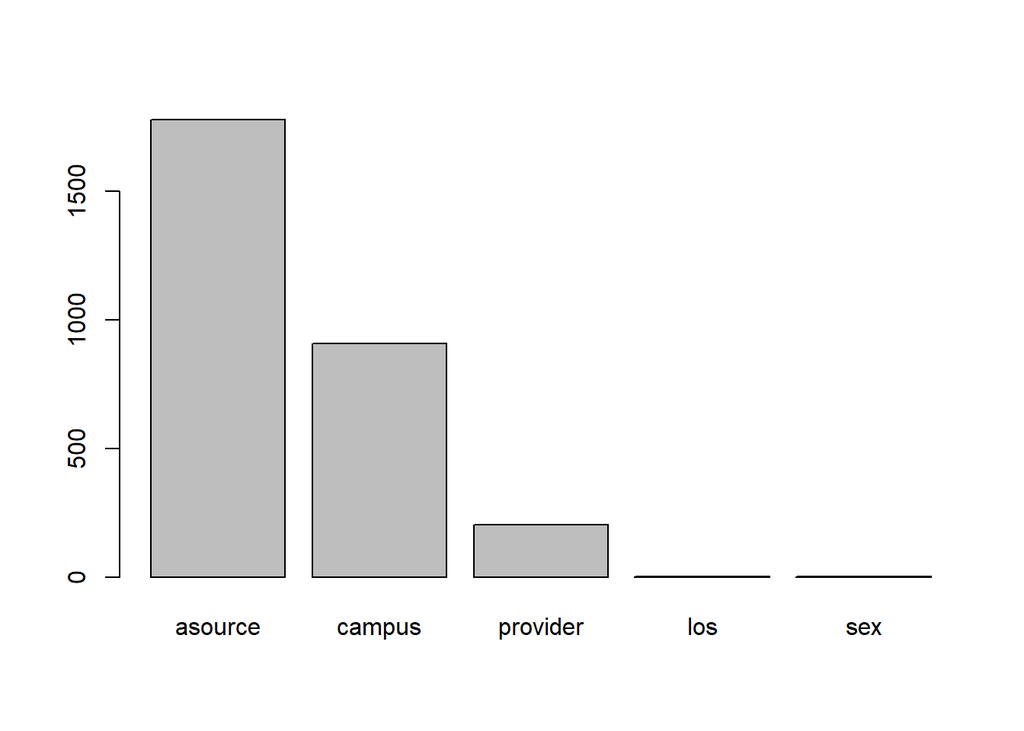

```r
barplot(tree_model$variable.importance)
```

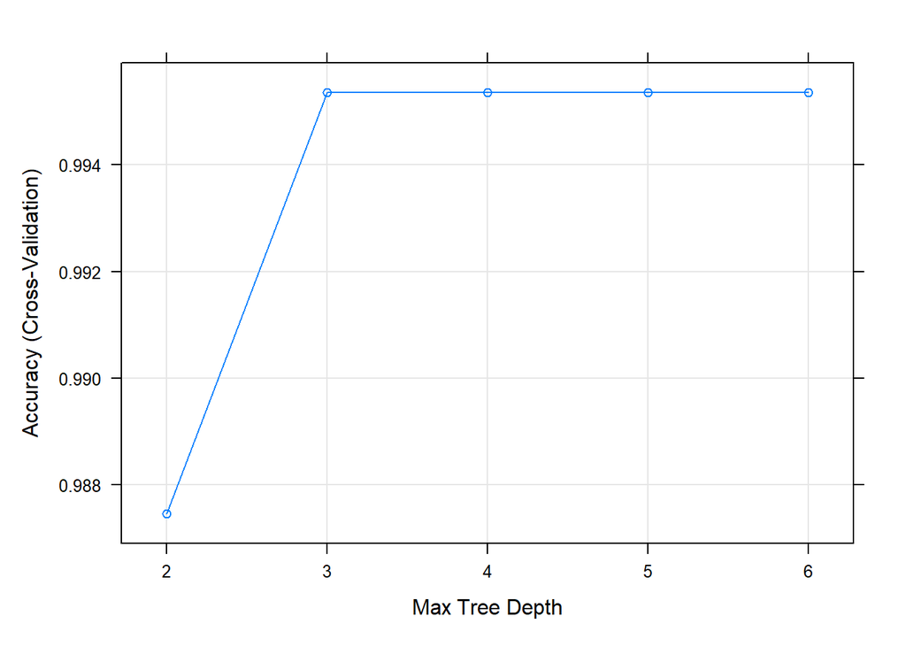

```r
# Decide the range of the maxdepth to search for the best
tuneGrid = expand.grid(maxdepth = 2:6)
# Cross-Validation
trControl = trainControl(method = "cv",
                         number = 5)
# first approach
approach1 <- train(target~., data=df_train,
                                method = "rpart2",
                                trControl = trControl,
                                tuneGrid = tuneGrid)

# Plot the results
plot(approach1)
```

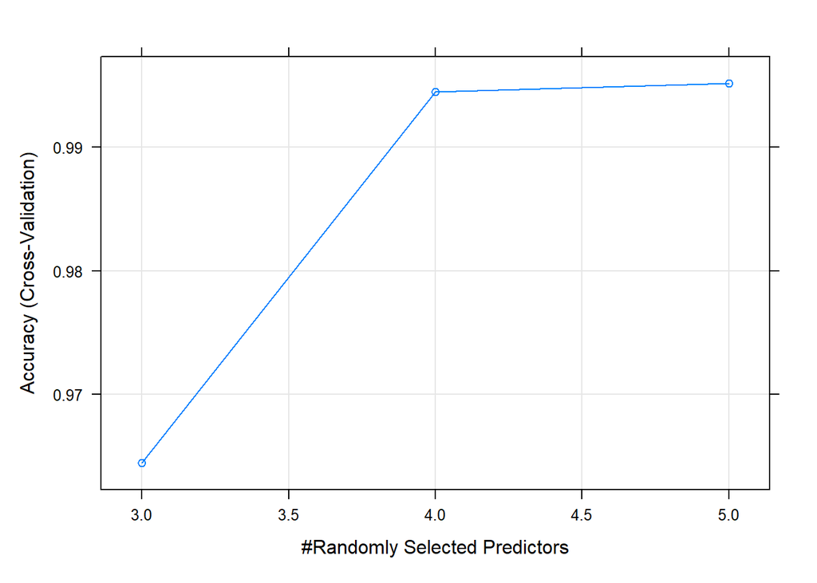

```r
# Random Forest Model

# Decide the range of the mtry to search for the best
tuneGrid = expand.grid(mtry = 3:5)
# Tell caret to do 10 - fold cross-Validation
trControl = trainControl(method = "cv",
                         number = 5)
# train a forest using above setup
forest_rf <- train(target~., data=df_train,
                                method = "rf",
                                trControl = trControl,
                                tuneGrid = tuneGrid)

plot(forest_rf)
```

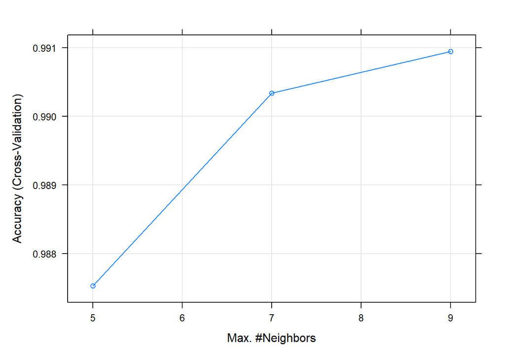

```r
trControl = trainControl(method = "cv",
                         number = 5)

knear <- train(target~., data=df_train,
                    method = "kknn",
                    trControl = trControl)
plot(knear)
```

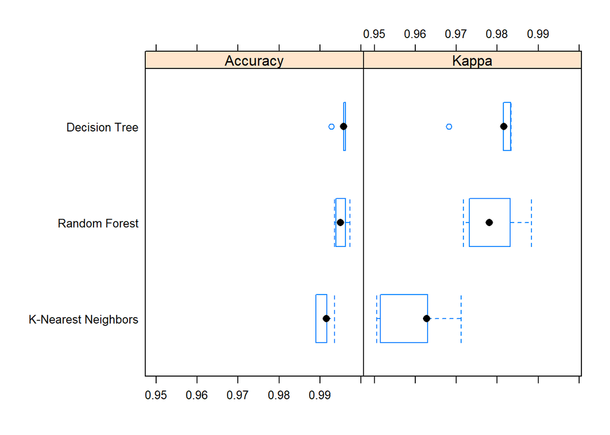

```r
results <- resamples(list('Decision Tree' = approach1,
                          'Random Forest' = forest_rf,
                          'K-Nearest Neighbors'= knear))
bwplot(results)
```

```r
# Best Model: Decision Tree

pred <- predict(approach1, df_test)
cm <- confusionMatrix(data = pred, reference = df_test$target, positive = "adult")
cm$overall[1]
```

```
##  Accuracy
## 0.9946505
```

Findings: